# Brazil Kinship Results

EA

2025-09-14

# Analysis Details:

This is a RMarkdown for the final analysis. To get to this step, you need a dataset from the filtered exploration RMarkdown and your metadata file.

# Adult Exploration / BSR / OSR

We have more males than females every season (in this analysis).

*I will need to go back and look at which female nest failed and how many females we lost in sequencing to get better picture of the breeding sex ratios. Our goal was to sequence every nest from every female over all four years but we may have lost a female’s nest, excluding her from these calculations*.

```
## BRAZIL S1: 19F, 35M
## BRAZIL S2: 25F, 50M
## BRAZIL S3: 39F, 63M
## BRAZIL S4: 44F, 71M
```

The breeding sex ratio is calculated as the #Males/#Females that actually contribute to reproduction in a population.

We get a breeding sex ratio of 1.42 meaning tha are about 1.4x breeding males as females.

The Operation Sex Ratio is calculated as the percentage of males in the breeding population: males/(males+females) × 100.

- We have a male biases OSR (>50%) which would typically lead to increased male-male competition.

```
## Overall breeding sex ratio: 1.42 (175 males : 123 females)
## Operational sex ratio: 58.7% males
```

```
## Season S1 breeding sex ratio: 1.84 (35 males : 19 females)
## Operational sex ratio: 64.8% males
## Season S2 breeding sex ratio: 2 (50 males : 25 females)
## Operational sex ratio: 66.7% males
## Season S3 breeding sex ratio: 1.62 (63 males : 39 females)
## Operational sex ratio: 61.8% males
## Season S4 breeding sex ratio: 1.61 (71 males : 44 females)
## Operational sex ratio: 61.7% males
```

The effective population size is calculated by `Ne = (4 * Nm * Nf) / (Nm + Nf)`. *Need to check with literature that this is the correct eqn*.

We have an effective population size of 288. *It would be interesting to compare this to other populations*.

```
## Overall effective breeding population size (Ne): 288.9
```

```
## Season S1 Ne: 49.3
## Season S2 Ne: 66.7
## Season S3 Ne: 96.4
## Season S4 Ne: 108.7
```

# Male Analysis

There are males that return for each season.

```
## Shared Fathers Between Seasons:
```

|  | S1 | S2 | S3 | S4 |
| --- | --- | --- | --- | --- |
| S1 | **35** | 5 | 10 | 11 |
| S2 | 5 | **50** | 5 | 12 |
| S3 | 10 | 5 | **63** | 13 |
| S4 | 11 | 12 | 13 | **71** |

These male reproductive success is based on our limited sample selection (choosing 16 vs 32 vs 96 hatchlings). *I will need to think about how to project this onto a full nest scale?*

```
## Male reproductive success: range 1-52, median 9
```

### Multiple Paternity

Over half of our nests exhibit multiple paternity. and that pattern is evident in every field season.

```
## Multiple paternity summary: median 2, proportion of nests with multiple fathers: 0.666666666666667
```

```
##
## Multiple Paternity per female (Descending order Top 15 ):
```

```
##                   mom count
##                <char> <int>
##  1: BR_CM_12_FDN_F052     7
##  2: BR_CM_11_FDN_F009     6
##  3: BR_CM_12_FDN_F045     5
##  4: BR_CM_13_FDN_F075     5
##  5: BR_CM_12_FDN_F072     4
##  6: BR_CM_12_FDN_F137     4
##  7: BR_CM_12_FDN_F091     4
##  8: BR_CM_12_FDN_F114     4
##  9: BR_CM_12_FDN_F117     4
## 10: BR_CM_13_FDN_F008     4
## 11: BR_CM_11_FDN_F074     4
## 12: BR_CM_12_FDN_F126     4
## 13: BR_CM_12_FDN_F056     4
## 14: BR_CM_12_FDN_F081     4
## 15: BR_CM_12_FDN_F095     4
```

```
##
## Multiple Paternity per season:
```

```
## Season S1 multiple paternity: mean 2.16, median 2, range 1-6, proportion 57.9%
## Season S2 multiple paternity: mean 2.6, median 2, range 1-7, proportion 76%
## Season S3 multiple paternity: mean 2.26, median 2, range 1-5, proportion 64.1%
## Season S4 multiple paternity: mean 1.91, median 2, range 1-4, proportion 63.6%
```

We have lower polygyny (males with multiple females) than polyandry (females with multiple males).

```
## Proportion of males mating with multiple females: 33.1%
```

```
## Season S1 polygyny rate: 17.1%
## Season S2 polygyny rate: 22%
## Season S3 polygyny rate: 25.4%
## Season S4 polygyny rate: 11.1%
```

### Temporal Patterns of Male Mating Success

One reconstructed father is present in all seasons (pa_22)

```
## Males appearing in multiple seasons:
```

```
##   23 males active in 2 seasons
##   9 males active in 3 seasons
##   1 males active in 4 seasons
```

```
##
## Top 15 Males and their active seasons
```

| dad | S1 | S2 | S3 | S4 | seasons_active |
| --- | --- | --- | --- | --- | --- |
| pa_22 | 3 | 15 | 2 | 13 | 4 |
| BR_CM_11_FDN_M015 | 8 | 2 | 0 | 18 | 3 |
| BR_CM_11_FDN_M023 | 2 | 4 | 0 | 14 | 3 |
| BR_CM_13_FDN_M017 | 2 | 0 | 18 | 26 | 3 |
| pa_140 | 3 | 0 | 15 | 3 | 3 |
| pa_145 | 12 | 0 | 17 | 6 | 3 |
| pa_153 | 1 | 2 | 0 | 6 | 3 |
| pa_20 | 2 | 0 | 21 | 16 | 3 |
| pa_19 | 0 | 22 | 21 | 9 | 3 |
| pa_44 | 0 | 11 | 2 | 28 | 3 |
| BR_CM_11_FDN_M019 | 26 | 0 | 5 | 0 | 2 |
| BR_CM_13_FDN_M010 | 1 | 0 | 0 | 6 | 2 |
| pa_11 | 15 | 0 | 11 | 0 | 2 |
| pa_110 | 4 | 16 | 0 | 0 | 2 |
| pa_152 | 2 | 0 | 0 | 1 | 2 |

#### Male Effects - Quick Checks

There is an affect with father type and offspring count (chi-squared). *Although I need to think about if this is a good test because we didn’t fully sample each nest*

```
##
## Chi-square test for uniform distribution of offspring among fathers:
```

```
## Chi-square = 1678.92, df = 174, p-value = < 2.2e-16
```

There is a father effect on offspring count within seasons as well.

```
##
## Season: S1
## Number of fathers: 35
## Chi-square = 245.04, df = 34, p-value = < 2.2e-16
##
## Season: S2
## Number of fathers: 50
## Chi-square = 307.35, df = 49, p-value = < 2.2e-16
##
## Season: S4
## Number of fathers: 71
## Chi-square = 579.7, df = 70, p-value = < 2.2e-16
##
## Season: S3
## Number of fathers: 63
## Chi-square = 426.66, df = 62, p-value = < 2.2e-16
```

There is no relationship between the father identify and the number of nests they contribute to (Kruskal Test pVal=0.48). This relationship is not seen at the season level either.

```
##
##  Kruskal-Wallis rank sum test
##
## data:  unique_nests by dad
## Kruskal-Wallis chi-squared = 174, df = 174, p-value = 0.4857
```

```
##
## Nest Contribution per father (top 6):
```

```
## # A tibble: 6 × 2
##   dad               nest_num
##   <chr>                <dbl>
## 1 pa_19                   10
## 2 pa_145                   8
## 3 BR_CM_11_FDN_M023        6
## 4 pa_140                   6
## 5 pa_22                    6
## 6 BR_CM_13_FDN_M008        5
```

```
##
## Effect of father on Nest Contribution per Season
```

```
##   season   p_value
## 1     S1 0.4677383
## 2     S2 0.4731283
## 3     S4 0.4761120
## 4     S3 0.4775188
```

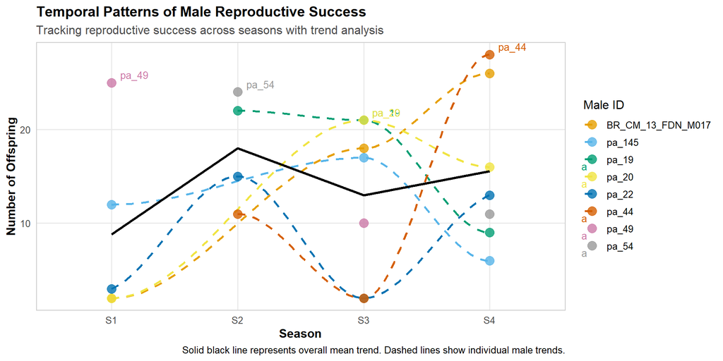

Investigating males from multiple seasons:

- **Proportional Success:** fraction of the total offspring in a given season were sired by a particular male. It shows a male’s reproductive success relative to all other males in that season. A higher value means the male sired a larger percentage of all offspring in that season.
- **Reproductive efficiency:** How many offspring a male produces per mate. A higher value means the male produces more offspring per female mate on average.

From the wilcox test, theres no real stat differences between male reproductive metrics between seasons. This helps us answer *Do males tend to become more or less successful (or efficient) between consecutive breeding seasons?* and we get the answer of *no*.

```
##
## Season-to-season success transitions using relative metrics:
## From S1 to S2 (5 males):
##   Proportional success: 2 increased, 3 decreased, 2 remained similar
##   Reproductive efficiency: 4 increased, 1 decreased, 0 remained similar
##   Proportional success Wilcoxon p-value: 1 (no significant difference)
```

```
##   Reproductive efficiency Wilcoxon p-value: 0.2785 (no significant difference)
##   Rank correlation between seasons: rho = 0.4, p = 0.5167 (no significant correlation)
## From S2 to S4 (12 males):
##   Proportional success: 5 increased, 7 decreased, 0 remained similar
##   Reproductive efficiency: 5 increased, 7 decreased, 0 remained similar
##   Proportional success Wilcoxon p-value: 0.2334 (no significant difference)
```

```
##   Reproductive efficiency Wilcoxon p-value: 0.9374 (no significant difference)
##   Rank correlation between seasons: rho = 0.126, p = 0.6997 (no significant correlation)
## From S4 to S3 (13 males):
##   Proportional success: 7 increased, 6 decreased, 1 remained similar
##   Reproductive efficiency: 6 increased, 7 decreased, 0 remained similar
##   Proportional success Wilcoxon p-value: 0.3396 (no significant difference)
```

```
##   Reproductive efficiency Wilcoxon p-value: 0.5289 (no significant difference)
##   Rank correlation between seasons: rho = -0.038, p = 0.9062 (no significant correlation)
```

There is a relationship between the number of mates and number of offspring for males (makes sense).

```
##
##
## Linear model summary:
```

```
##
## Call:
## lm(formula = total_offspring ~ unique_mates, data = mate_offspring_corr)
##
## Residuals:
##     Min      1Q  Median      3Q     Max
## -19.611  -7.525  -3.525   4.475  26.432
##
## Coefficients:
##              Estimate Std. Error t value Pr(>|t|)
## (Intercept)    4.5037     1.2628   3.566 0.000468 ***
## unique_mates   5.0215     0.6661   7.539 2.56e-12 ***
## ---
## Signif. codes:  0 '***' 0.001 '**' 0.01 '*' 0.05 '.' 0.1 ' ' 1
##
## Residual standard error: 9.493 on 173 degrees of freedom
## Multiple R-squared:  0.2473, Adjusted R-squared:  0.2429
## F-statistic: 56.83 on 1 and 173 DF,  p-value: 2.558e-12
```

### Reproductive Skew Within Clutches

Wanting to see if there are certain males that may dominate nests and their trends.

```
## Analysis of reproductive skew within multiply-sired clutches:
```

```
## Number of multiply-sired clutches: 82
```

```
##
## Reproductive skew summary statistics:
```

```
## Mean proportion from primary father: 0.674
```

```
## Mean evenness index (0-1, where 1 = perfectly even): 0.748
```

```
## Mean binomial skew index: 1.267 (values > 0 indicate skew)
```

```
##
## Categories of reproductive skew:
```

```
##   High skew: 26 clutches (31.7%)
##   Low skew: 9 clutches (11%)
##   Moderate skew: 47 clutches (57.3%)
```

```
##
## Seasonal variation in reproductive skew:
##   Season S1 (n = 11): Primary father proportion = 0.619, Evenness = 0.8
##   Season S2 (n = 19): Primary father proportion = 0.624, Evenness = 0.82
##   Season S4 (n = 28): Primary father proportion = 0.734, Evenness = 0.702
##   Season S3 (n = 25): Primary father proportion = 0.67, Evenness = 0.728
##
## Kruskal-Wallis test for seasonal differences in skew-ness:
##   Chi-squared = 7.2, df = 3, p-value = 0.0657 (not significant)
```

Within nests, the primary father makes up most of the hatchlings and this is found across seasons as well. The distribution is normally distributed. It can suggests there may be *some sexual selection?* but they are not totally monopolizing all nests?

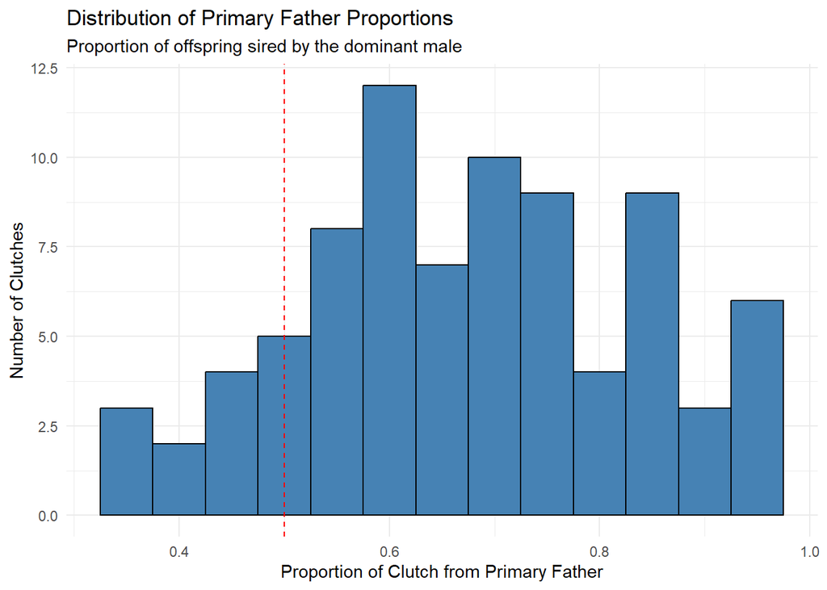

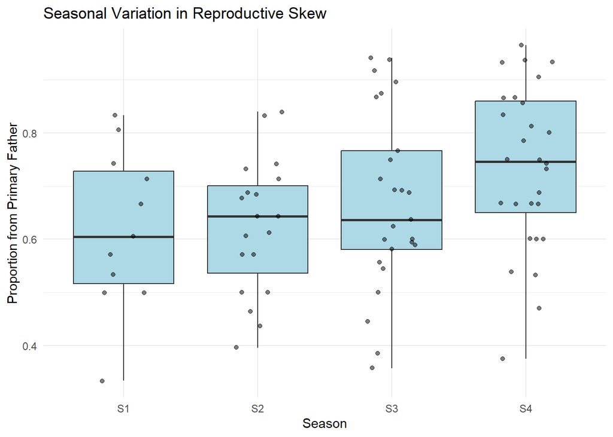

## Breeding Networks

**Basic Mating Network Metrics**

```
## Number of nodes (parents): 298
```

```
## Number of edges (mating connections): 273
```

**Key breeders in the network**

```
##
## Top central individuals in mating network:
```

```
## # A tibble: 298 × 5
## # Groups:   parent_type [2]
##    parent_id         in_degree out_degree betweenness parent_type
##    <chr>                 <dbl>      <dbl>       <dbl> <chr>
##  1 BR_CM_13_FDN_M009         2          0           0 Father
##  2 pa_1                      1          0           0 Father
##  3 pa_2                      1          0           0 Father
##  4 BR_CM_11_FDN_M015         3          0           0 Father
##  5 pa_3                      2          0           0 Father
##  6 pa_4                      1          0           0 Father
##  7 pa_6                      2          0           0 Father
##  8 pa_5                      2          0           0 Father
##  9 pa_7                      2          0           0 Father
## 10 pa_8                      1          0           0 Father
## # ℹ 288 more rows
```

```
##
## Mating community detection: groups that mate more with each other
```

```
## Number of communities detected: 50
```

```
##
## Similarity between seasonal networks (Jaccard index):
##   S1 vs S2: 0 (0 shared connections)
##   S1 vs S4: 0.0081 (1 shared connections)
##   S1 vs S3: 0.0078 (1 shared connections)
##   S2 vs S4: 0 (0 shared connections)
##   S2 vs S3: 0.0066 (1 shared connections)
##   S4 vs S3: 0.0059 (1 shared connections)
```

```
##
## Detailed analysis of shared connections between seasons:
##
##   Seasons S1 and S2 have no shared connections.
##
##   Seasons S1 and S4 share 1 connections:
##     BR_CM_11_FDN_F001 → pa_152
##
##   Shared mothers (1): BR_CM_11_FDN_F001
##   Shared fathers (1): pa_152
##
##   Seasons S1 and S3 share 1 connections:
##     BR_CM_11_FDN_F005 → pa_145
##
##   Shared mothers (1): BR_CM_11_FDN_F005
##   Shared fathers (1): pa_145
##
##   Seasons S2 and S4 have no shared connections.
##
##   Seasons S2 and S3 share 1 connections:
##     BR_CM_11_FDN_F060 → pa_142
##
##   Shared mothers (1): BR_CM_11_FDN_F060
##   Shared fathers (1): pa_142
##
##   Seasons S4 and S3 share 1 connections:
##     BR_CM_12_FDN_F113 → pa_20
##
##   Shared mothers (1): BR_CM_12_FDN_F113
##   Shared fathers (1): pa_20
```

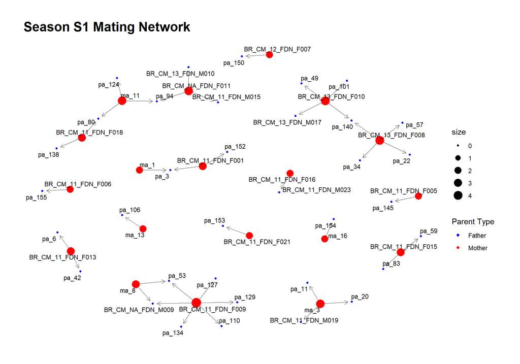

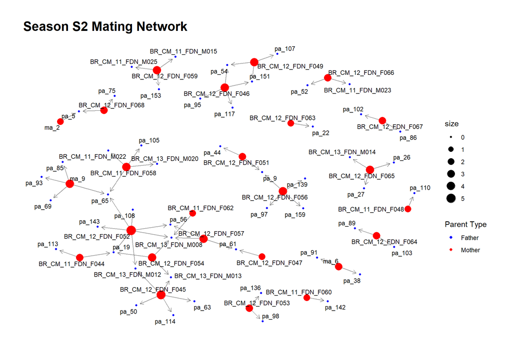

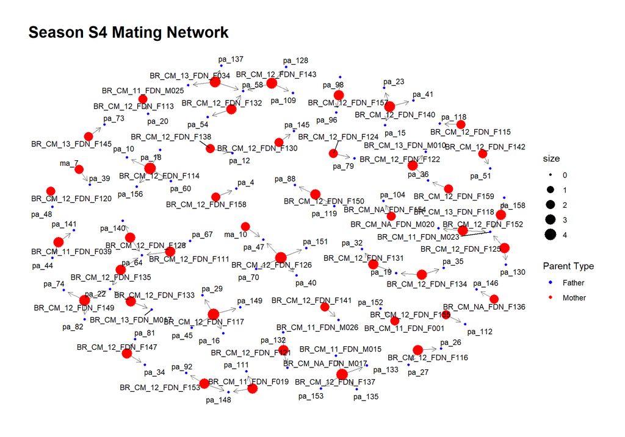

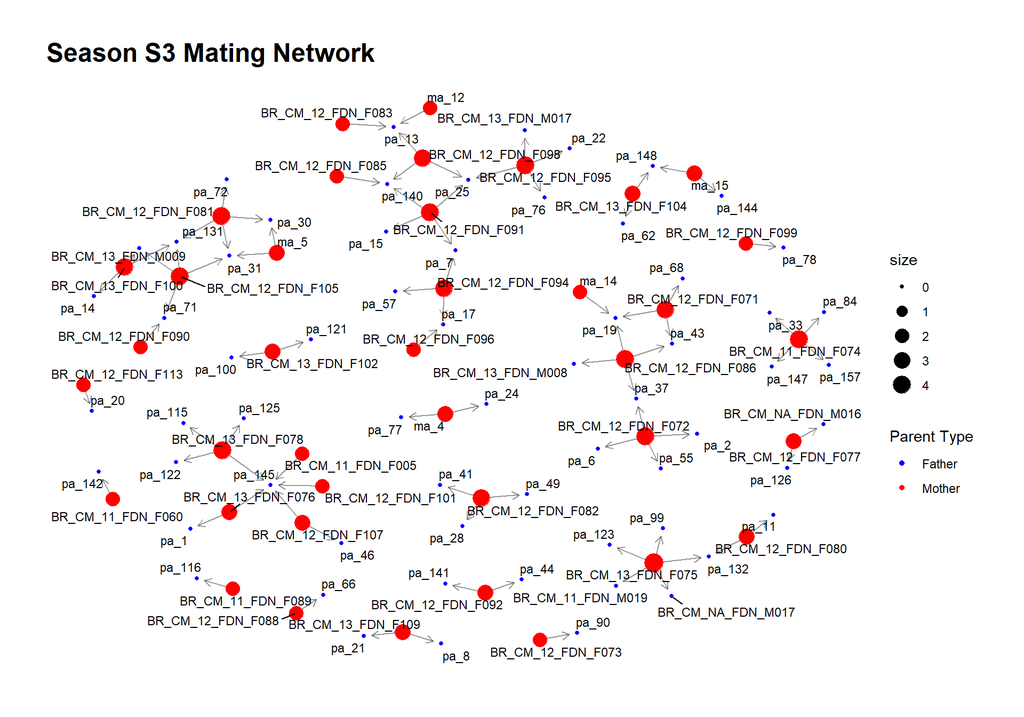

## Power Analysis:

I am still wrapping my mind on this code.